# Indicators of Habitat and Ecosystem Change

Matt Dzaugis

2022-01-13

## Developing Indicators of Habitat and Ecosystem Change in the Gulf of Maine

### Study area

The focus area for this project is coastal Maine, extending from the coast to the eastern boundary of the NOAA statistical areas 511, 512, 513.

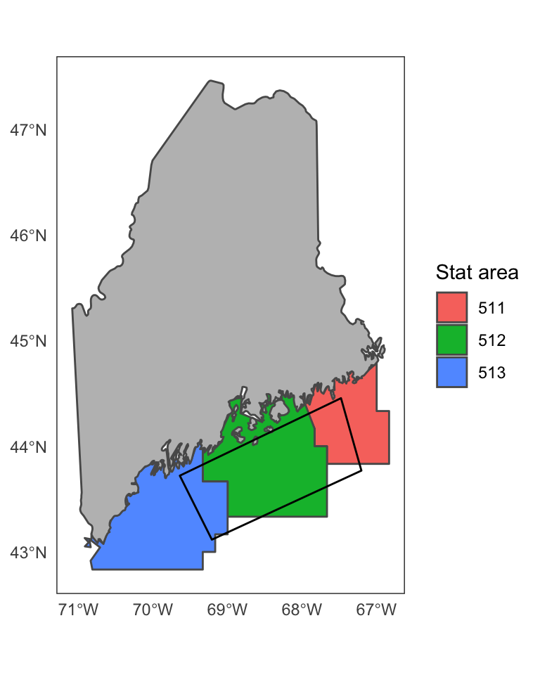

Study region. NOAA statistical areas are indicated as colored polygons. Maine coastal current study region indicated by the black outlined open polygon

```r
usStates <- rnaturalearth::ne_states("united states of america", returnclass = "sf")
ne_us <- usStates %>% filter(name == "Maine")
statarea <- sf::st_read(paste0(gmRi::shared.path(group = "Res_Data", folder = "Shapefiles/Statistical_Areas"), "Statistical_Areas_2010_withnames.shp"), quiet = TRUE) %>%
  filter(Id %in% c(511, 512, 513)) %>%
  mutate(Id = as.factor(Id))
statarea_sf <- sf::st_simplify(statarea, dTolerance = .05)
mcc_turnoff_sf <- sf::st_read(here::here("Data/Shapefiles/MCC_turnoff/MCC_turnoff.shp"), quiet = TRUE)

ggplot() +
  geom_sf(data = statarea_sf, aes(fill = Id)) +
  geom_sf(data= ne_us, fill = "grey") +
  geom_sf(data = mcc_turnoff_sf, fill = "transparent", color = "black") +
  scale_fill_discrete(name = "Stat area") +
  theme(panel.background = element_blank(),
        panel.grid = element_blank(),
        axis.title = element_blank(),
        axis.ticks = element_blank())
```

### Indicators

The following indicators are used in this report

- Surface and bottom temperature anomalies (FVCOM, OISST)
- Surface and bottom salinity anomalies (FVCOM)
- Maine Coastal Current Index (FVCOM)
- Species-based lobster predator index (NOAA Trawl Survey)
- Continuous Plankton Recordings

```r
# Indicators
allIndicators <- read_csv(here::here("Processed_Indicators/allIndicators.csv"))
allIndicators$Season <- factor(allIndicators$Season, levels= c("spring", "summer", "fall", "winter", "all"))
allIndicators$stat_area <- factor(allIndicators$stat_area, levels= c("511", "512", "513", "511-513"))
indicators <- unique(allIndicators$Indicator)
```

### Indicators PCA

Previous analysis shows surface and bottom temperature and surface and bottom salinity load similarly in a PCA. To reduce variables only bottom temperature and salinity are used in the following PCA.

#### PCA Summary

The first three principal components have eigenvalues greater than one and were retained for further analysis. PC1 and PC2 explain 34.5% and 24.8% of the variability, respectively. PC3 explains an additional 14.4% of the variability.

```r
indicator_list <- c("fvcom_bt", "fvcom_bs","mcc", "nefsc_abundance", "nefsc_size_spectra_slope", "cpr_FirstMode", "cpr_SecondMode")

allIndex <- allIndicators %>%
  filter(Season == "all",
         stat_area == "511-513",
         Indicator %in% indicator_list) %>%
  select(-Season, -stat_area) %>%
  pivot_wider(names_from = Indicator, values_from = Value) %>%
  na.omit()

### Composite PCA (combined stat areas)
indicator_pca <- allIndex %>% column_to_rownames(., var = "Year") %>%
  prcomp(scale. = TRUE, center = TRUE)

index_pca <- tibble("PC1" = indicator_pca$x[,1],
                    "PC2" = indicator_pca$x[,2],
                    "PC3" = indicator_pca$x[,3])
index_pca["Year"] <- allIndex$Year

pc_importance <- summary(indicator_pca)$importance[, 1:5]

knitr::kable(pc_importance)
```

|  | PC1 | PC2 | PC3 | PC4 | PC5 |
| --- | --- | --- | --- | --- | --- |
| Standard deviation | 1.553006 | 1.317107 | 1.005198 | 0.8982436 | 0.7340564 |
| Proportion of Variance | 0.344550 | 0.247820 | 0.144350 | 0.1152600 | 0.0769800 |
| Cumulative Proportion | 0.344550 | 0.592370 | 0.736720 | 0.8519800 | 0.9289600 |

```r
scree1 <- fviz_eig(indicator_pca, ylab = "% variance explained") + scale_y_continuous(limits = c(0,60))

#scree1 / scree2 / scree3
```

#### PC time series

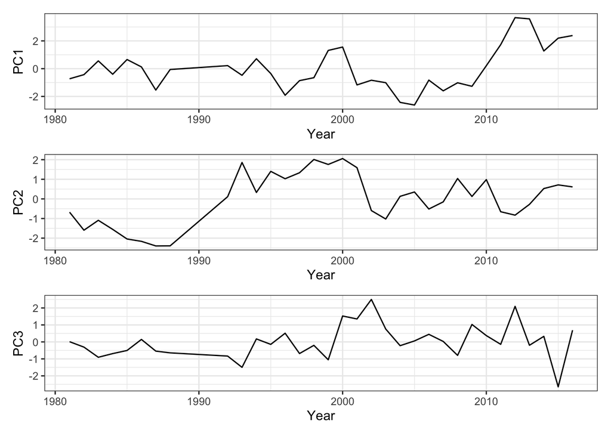

```r
PC1plot <- index_pca %>%
  ggplot() +
  geom_line(aes(Year, PC1))

PC2plot <- index_pca %>%
  ggplot() +
  geom_line(aes(Year, PC2))

PC3plot <- index_pca %>%
  ggplot() +
  geom_line(aes(Year, PC3))


PC1plot / PC2plot / PC3plot
```

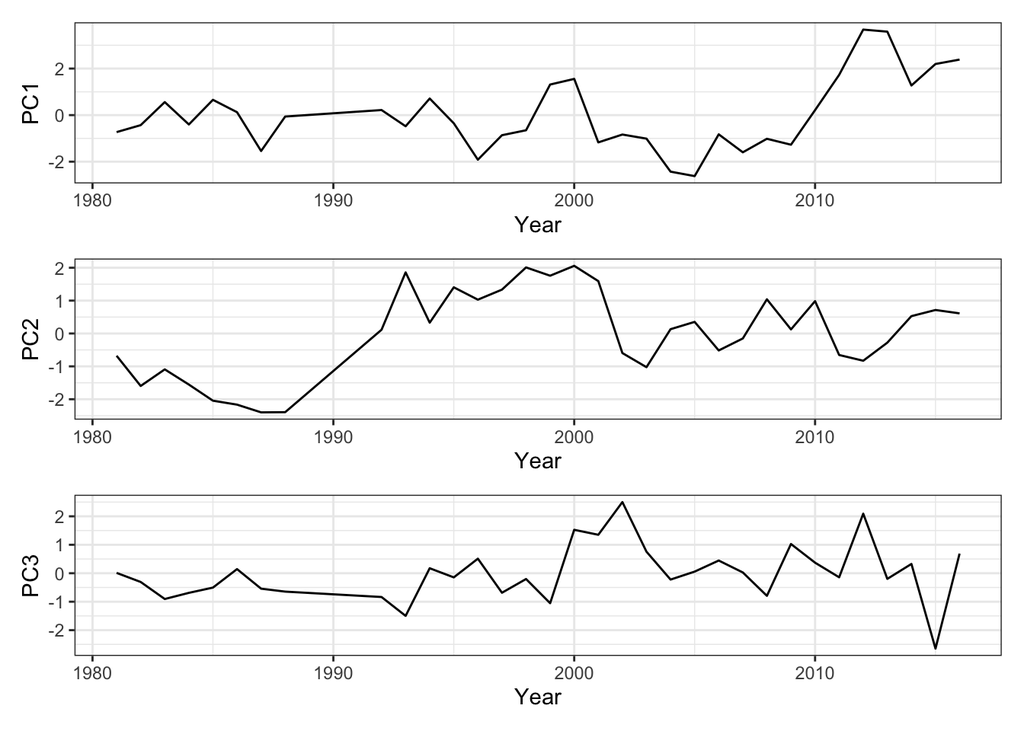

```r
### Maine composite

PC1plot <- index_pca %>%
  ggplot() +
  geom_line(aes(Year, PC1))

PC2plot <- index_pca %>%
  ggplot() +
  geom_line(aes(Year, PC2))

PC3plot <- index_pca %>%
  ggplot() +
  geom_line(aes(Year, PC3))

PC1plot / PC2plot / PC3plot
```

#### Loadings plot

Interpretation:

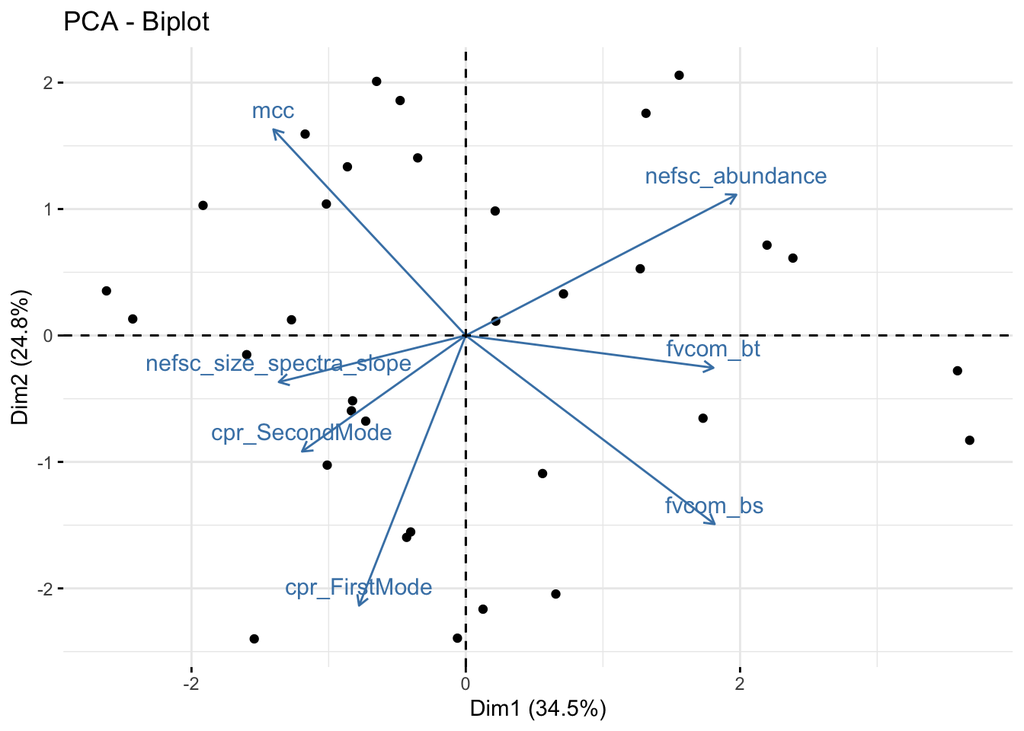

Figure 4. Loadings of the variables

| Indicator | PC1 | PC2 | PC3 |
| --- | --- | --- | --- |
| fvcom_bt | 0.447 | -0.075 | 0.543 |
| fvcom_bs | 0.449 | -0.436 | 0.043 |
| mcc | -0.347 | 0.476 | 0.266 |
| nefsc_abundance | 0.489 | 0.325 | 0.300 |
| nefsc_size_spectra_slope | -0.338 | -0.107 | 0.686 |
| cpr_FirstMode | -0.193 | -0.624 | 0.031 |
| cpr_SecondMode | -0.296 | -0.268 | 0.266 |

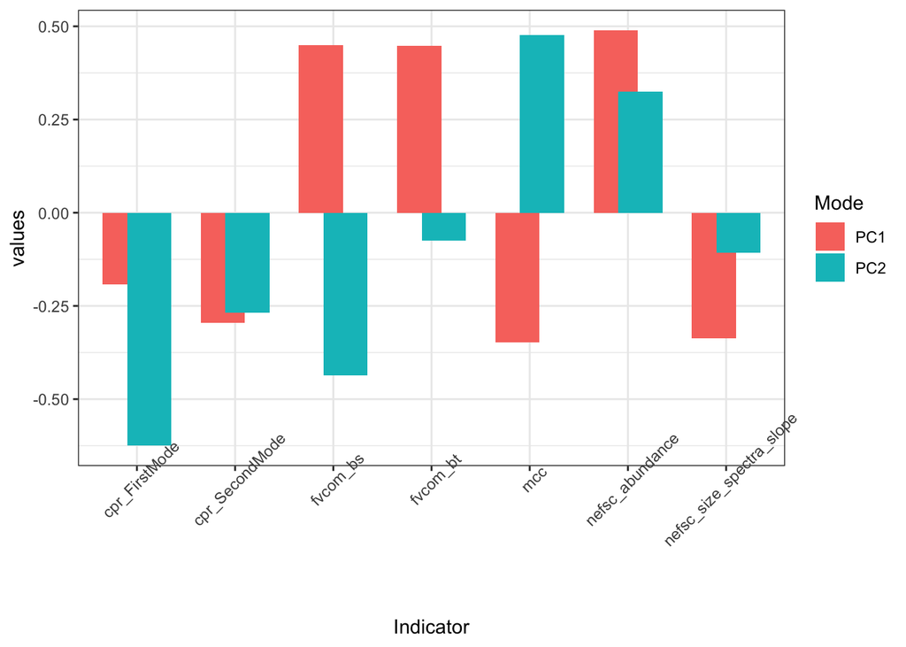

Figure 4. Loadings of the variables